# 2 Introduction

What is Secure Multi-Party Computation?

- Joint computation of a function
- Secret inputs
- Only final result is revealed

Examples:

- Millionaire’s problem
- Secret Santa
- Electronic voting
- Auctions
- Machine learning

# 3 MPC Basics

- Lagrange Interpolation
  - Set of *t* + 1 points uniquely identify a polynomial of degree ≤ *t*
- Shamir’s Secret Sharing
  - (*t*,*m*)-threshold secret sharing scheme based on Lagrange Interpolation
  - $≥$ *t* + 1 shares to reconstruct the secret *S*
  - Choose random polynomial *f*(*x*) of degree *t* where *f*(0) = *S*
  - Share *s*<sub>*i*</sub> = *f*(*i*), for *i* ∈ [1,*m*]
- Secure Multi-Party Computation
  - *m* parties jointly compute a function *f*(*S*<sub>1</sub>,*S*<sub>2</sub>,…,*S*<sub>*m*</sub>), from their secret inputs
  - Party *i* secret shares its private input *S*<sub>*i*</sub> with the others
  - Interactive protocol to reconstruct a polynomial *g*(*x*), where *g*(0) = *f*(*S*<sub>1</sub>,*S*<sub>2</sub>,…,*S*<sub>*m*</sub>)

# 4 Problem Description

MPyC:

- Python framework for MPC developed at TU/e
- No service discovery yet
- Target users of different level of expertise
  - Casual
  - Power
  - Enterprise
- MPC is Peer-to-Peer
- Local networks are tricky
  - Limited supply of IPv4 addresses
  - Slow adoption of IPv6
  - Network Address Translation (NAT)

# 5 Research Questions

*How can MPyC be extended to enable casual users, power users and enterprises with limited prior knowledge of each other to discover each other and perform a secure multiparty computation under diverse networking conditions?*

- deployment strategies?
- identity?
- first contact?
- connectivity?
  - security?
  - privacy?
  - performance?

# 6 Preparation Phase Scope

- Technical Survey
- Extensible Evaluation Environment (*E*<sup>3</sup>) - network of host machines for MPC
  - Simple
  - Extensible
  - Cross region
  - Cross platform
  - Automated
  - Reproducible
  - Disposable
- Implementation Phase Planning

# 7

# 8 Technical Survey

- Deployment tools
- Connectivity approaches

# 9 Infrastructure as Code (IaC)

Tools:

- Provisioning - Terraform, CloudFormation
- Deployment - Ansible, Puppet, Chef

Specification:

- Imperative - describes the steps to execute
- Declarative - describes the desired state

Operating Systems:

- Most Linux distributions are imperatively managed
- NixOS
  - Declarative
  - Deployment tools: NixOps, Colmena, morph, deploy-rs

# 10 Virtual Private Networks (VPNs)

- Centralized VPNs - OpenVPN, IPSec
  - Emulate a real network
  - Transparent to the other programs on the host
  - Single point of failure
  - Can be bottlenecked
- Mesh VPNs - Tailscale, Nebula, Tinc
  - Peer-to-Peer traffic
  - Discovery can happen via a public service or from a known peer

# 11 Network Address Translation (NAT)

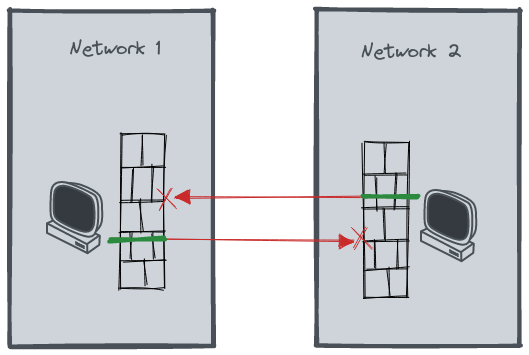

“Two parties behind separate NATs”

- Parties behind a NAT device (usually their router)
  - Can initiate a connection to a public endpoint
  - Cannot be discovered from the outside
  - Neither party can initiate the connection to the other

# 12 NAT Traversal

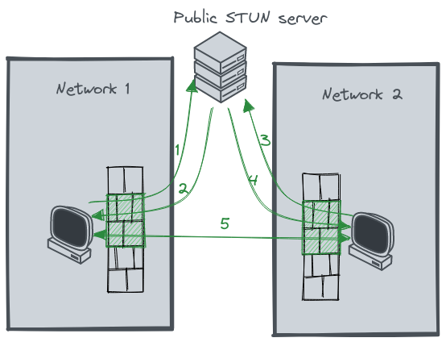

“NAT traversal via STUN”

- Session Traversal Utilities for NAT (STUN)
  - Parties connect to a public STUN server (can be another party)
  - The server reports the IPs it “sees” the parties at
  - User Datagram Protocol (UDP) hole punching
    - Reverse channel for the STUN server to talk back to a party
    - Appropriated by the other parties for their own traffic

# 13 Other approaches

- Decentralized identifiers (DIDs) and DIDComm
  - Lack of sessions
  - Inefficient for MPC
- The Onion Router
  - Privacy
  - Onion services
- Peer-to-peer applications
  - Bit Torrents
  - Ethereum
  - IPFS

# 14

# 15 Reference Implementation

- DigitalOcean - cloud provider
- RaspberryPi - ARM based Single Board Computer (SBC)
- NixOS - declarative Linux distribution
- Terraform - declarative provisioning
- Colmena - declarative NixOS deployment
- Tailscale - mesh VPN as a Service
- prsync - sync directories to multiple hosts over ssh
- pssh - execute commands on multiple hosts in parallel over ssh

# 16 Nix - Basic flake.nix

```
{
  inputs = {
    nixpkgs.url = "github:nixos/nixpkgs/nixos-unstable";
  };

  outputs = inputs@{ self, nixpkgs, ... }:
    let
      pkgs = import nixpkgs {
        system = "x86_64-linux";
      };
    in
    {
        myHello = pkgs.hello;
    };
}
```

# 17 Nix - flake.lock

```
{
  "nodes": {
    "nixpkgs": {
      "locked": {
        "lastModified": 1666377499,
        "narHash": "sha256-dZZCGvWcxc7oGnUgFVf0UeNHsJ4VhkTM0v5JRe8EwR8=",
        "owner": "nixos",
        "repo": "nixpkgs",
        "rev": "301aada7a64812853f2e2634a530ef5d34505048",
        "type": "github"
      },
      "original": {
        "owner": "nixos",
        "ref": "nixos-unstable",
        "repo": "nixpkgs",
        "type": "github"
      }
    },
    ...
  }
}
```

# 18 Nix - Development Shell

```
  devShell.x86_64-linux = pkgs.mkShell {
    shellHook = ''
      export PYTHONPATH=./
    '';

    nativeBuildInputs = [
      pkgs.curl pkgs.jq
      pkgs.colmena pkgs.pssh
      (pkgs.terraform.withPlugins
        (tp: [
          tp.digitalocean tp.null
          tp.external tp.tailscale
          tp.random
        ]))
      mpyc-demo
    ];
  };
```

# 19 Nix - MPyC Package

```
{ pkgs, dir }:
(pkgs.poetry2nix.mkPoetryEnv {
    python = pkgs.python3;
    projectDir = dir;
    extraPackages = (ps: [(pkgs.python3Packages.buildPythonPackage {
          name = "mpyc";
          src = dir;
        })]);
    overrides = pkgs.poetry2nix.overrides.withDefaults (
      self: super: {
        gmpy2 = pkgs.python3Packages.gmpy2;
      }
    );
  })
```

# 20 Nix - DigitalOcean Image (1)

```
## flake.nix
{
  inputs = {
    nixpkgs.url = "github:nixos/nixpkgs/nixos-unstable";
  };
  outputs = inputs@{ self, nixpkgs, ... }:
    let
      mpyc-demo = (import ./nix/mpyc-demo.nix { inherit pkgs; dir = ./.; });
      pkgs = import nixpkgs {
        system = "x86_64-linux";
      };
      digitalOceanConfig = import ./nix/digitalocean/image.nix {
        inherit pkgs;
        extraPackages = [ mpyc-demo ];
      };
    in
    {
        packages.digitalOceanImage = (pkgs.nixos digitalOceanConfig).digitalOceanImage;
    };
}
```

# 21 Nix - DigitalOCean Image (2)

```
## nix/digitalocean/image.nix
{ pkgs, extraPackages ? [ ], ... }:
{
  imports = [ "${pkgs.path}/nixos/modules/virtualisation/digital-ocean-image.nix" ];
  system.stateVersion = "22.11";
  environment.systemPackages = with pkgs; [
    jq
  ] ++ extraPackages;

  services.tailscale.enable = true;

  networking.firewall = {
    enable = true;
    checkReversePath = "loose";
    trustedInterfaces = [ "tailscale0" ];
  };
}
```

# 22 Nix - RaspberryPi Image

```
let
  mpyc-demo = (import ./nix/mpyc-demo.nix { inherit pkgs; dir = ./.; });

  pkgs = import nixpkgs {
    system = "aarch64-linux";
  };
in
{
    packages.raspberryPi4Image = (pkgs.nixos ({ config, ... }: {
        system.stateVersion = "22.11";
        imports = [
          ("${pkgs.path}/nixos/modules/installer/sd-card/sd-image-aarch64-installer.nix")
        ];

        environment.systemPackages = [
            mpyc-demo
        ];
    })).sdImage;
};
```

# 23 Terraform - Image Import

```
resource "digitalocean_spaces_bucket_object" "nixos-image" {
  region = digitalocean_spaces_bucket.tf-state.region
  bucket = digitalocean_spaces_bucket.tf-state.name
  key    = basename(var.nixos-image-path)
  source = var.nixos-image-path
  acl    = "public-read"
  etag   = filemd5(var.nixos-image-path)
}

resource "digitalocean_custom_image" "nixos-image" {
  name    = "nixos-22.11"
  url     = "https://${digitalocean_spaces_bucket.tf-state.bucket_domain_name}/${digitalocean_spaces_bucket_object.nixos-image.key}"
  regions = local.all_regions
  tags    = ["nixos"]

  lifecycle {
    replace_triggered_by = [
      digitalocean_spaces_bucket_object.nixos-image
    ]
  }
}
```

# 24 Terraform - Hostname Generation

```
locals {
  node_definitions = var.DESTROY_NODES != "" ? [] : [
    { region = "ams3", num = 3 },
    { region = "sfo3", num = 1 },
    { region = "nyc3", num = 1 },
    { region = "sgp1", num = 1 },
  ]
  nodes_expanded = flatten([
    for node in local.node_definitions : [
      for i in range(node.num) :
      merge(node, {
        name = "mpyc-demo--${node.region}-${i}"
      })
    ]
  ])
  nodes = {
    for node in local.nodes_expanded :
    node.name => merge(node, {
      hostname = "${node.name}-${random_id.mpyc-node-hostname[node.name].hex}"
    })
  }
}
```

# 25 Terraform - DigitalOcean Droplets

```
resource "digitalocean_droplet" "mpyc-node" {
  for_each = local.nodes

  image    = digitalocean_custom_image.nixos-image.id
  name     = each.value.hostname
  region   = each.value.region
  size     = "s-1vcpu-1gb"
  ssh_keys = [for key in digitalocean_ssh_key.ssh-keys : key.fingerprint]

  provisioner "remote-exec" {
    inline = [
      "mkdir -p /var/keys/",
      "echo ${tailscale_tailnet_key.keys.key} > /var/keys/tailscale",
      "tailscale up --auth-key file:/var/keys/tailscale"
    ]
  }
}

resource "tailscale_tailnet_key" "keys" {
  ...
}
```

# 26 Colmena

```
let
  mpyc-demo = (import ./nix/mpyc-demo.nix { inherit pkgs; dir = ./.; });

  pkgs = import nixpkgs {
    system = "x86_64-linux";
  };

  digitalOceanConfig = import ./nix/digitalocean/image.nix {
    inherit pkgs;
    extraPackages = [ mpyc-demo ];
  };
in
{
  packages.colmena = {
    meta = {
      nixpkgs = pkgs;
    };
    defaults = digitalOceanConfig;
  } // builtins.fromJSON (builtins.readFile ./hosts.json);
};
```

# 27 Colmena - hosts.json

```json
## hosts.json
{
  "mpyc-demo--ams3-0-15e53f39": {},
  "mpyc-demo--ams3-1-b4791c55": {},
  "mpyc-demo--ams3-2-7f09fb08": {},
  "mpyc-demo--nyc3-0-7dd0d9f6": {},
  "mpyc-demo--sfo3-0-5bffc60e": {},
  "mpyc-demo--sgp1-0-92700733": {}
}
```

# 28 Runtime

```bash
prsync -h hosts.pssh -zarv -p 4 ./ /root/mpyc
pssh -h hosts.pssh -iv -o ./logs/$t "cd /root/mpyc && ./prun.sh"
```

```bash
# assemble $args and $MY_PID from the hosts.pssh file

...


if [ $MY_PID = -1 ]
then
    echo Only $i parties are allowed. $HOSTNAME will not participate in this MPC session
else

cmd="python ./demos/secretsanta.py 3 --log-level debug \
    -I ${MY_PID} \
    ${args}"

echo $cmd
$cmd
fi
```

# 29

# 30 Demo

- Provisioning with Terraform
- Deployment with Colmena
- Running a distributed MPyC program
- Destruction of the infrastructure

# 31

# 32 Planning - connectivity implementations

- Headscale
- Nebula - IP allocation, Certificate authority, Certificate distribution
- Mesh VPN with alternative identity management
  - MPC based CA
  - Decentralized Identifiers
- DIDComm
  - sessions
  - NAT traversal
- TOR, Ethereum, IPFS
- Carbyne stack

# 33 Planning - analysis

Compare the implementations in terms of:

- Security
- Performance
- Ease of use
- Privacy